# R Notebook

knitr is a helpful package

it brings together many features added onto Sweave

knitr uses R as the programming language but integrates Latex, Markdown, HTML

knitr was developed by Yihui Xie, while a graduate student

Defining the Ideal Data Set

- Descriptive: a whole population
- Exploratory: A rondom sample with many variables
- Inferential: the right population, randomly sampled
- predictive: a training and test data set from the same population
- causal: data from a randomized study
- Mechanistic: data about the components of the system

# data centers

- Google Data Centers
- UCI Machine Learning Repository

# Steps in a data analysis

1. define the question
2. define the ideal data set
3. determine what data youo can access
4. obtain data
5. clean data
6. Exploratory data analysis
7. Statistical modeling
8. interpret results
9. challenge results
10. Write up results 11 create reproducible code

```r
# If not installed, install kernlab package
library(kernlab)
data(spam)
dim(spam)
```

```
[1] 4601   58
```

```r
str(spam[, 1:10])
```

```
'data.frame':   4601 obs. of  10 variables:
 $ make    : num  0 0.21 0.06 0 0 0 0 0 0.15 0.06 ...
 $ address : num  0.64 0.28 0 0 0 0 0 0 0 0.12 ...
 $ all     : num  0.64 0.5 0.71 0 0 0 0 0 0.46 0.77 ...
 $ num3d   : num  0 0 0 0 0 0 0 0 0 0 ...
 $ our     : num  0.32 0.14 1.23 0.63 0.63 1.85 1.92 1.88 0.61 0.19 ...
 $ over    : num  0 0.28 0.19 0 0 0 0 0 0 0.32 ...
 $ remove  : num  0 0.21 0.19 0.31 0.31 0 0 0 0.3 0.38 ...
 $ internet: num  0 0.07 0.12 0.63 0.63 1.85 0 1.88 0 0 ...
 $ order   : num  0 0 0.64 0.31 0.31 0 0 0 0.92 0.06 ...
 $ mail    : num  0 0.94 0.25 0.63 0.63 0 0.64 0 0.76 0 ...
```

we need to generate a test and training set (prediction)

```r
set.seed(3435)
train_indicator <-
    rbinom(n = 4601, size=1, prob = 0.5)
table(train_indicator)
```

```
train_indicator
   0    1
2314 2287
```

```r
trainspam = spam[train_indicator==1, ]
testspam = spam[train_indicator==0, ]
```

### Exploratory Data Analysis

- look at summaries of the data
- check for missing data
- create exploratory plots
- perform exploratory analyses (e.g. clustering)
- one/two dimensional relations

```r
names(trainspam)[1:5]
```

```
[1] "make"    "address" "all"     "num3d"   "our"
```

```r
head(trainspam)
```

|  | make | address | all | num3d | our | over | remove | internet | order | mail | receive | will | people | report | addresses | free | business | email | you | credit | your | font | num000 | money | hp | hpl | george | num650 | lab | … |
| --- | --- | --- | --- | --- | --- | --- | --- | --- | --- | --- | --- | --- | --- | --- | --- | --- | --- | --- | --- | --- | --- | --- | --- | --- | --- | --- | --- | --- | --- | --- |
| 1 | 0.00 | 0.64 | 0.64 | 0 | 0.32 | 0.00 | 0.00 | 0 | 0.00 | 0.00 | 0.00 | 0.64 | 0.00 | 0 | 0 | 0.32 | 0 | 1.29 | 1.93 | 0.00 | 0.96 | 0 | 0 | 0.00 | 0 | 0 | 0 | 0 | 0 | … |
| 7 | 0.00 | 0.00 | 0.00 | 0 | 1.92 | 0.00 | 0.00 | 0 | 0.00 | 0.64 | 0.96 | 1.28 | 0.00 | 0 | 0 | 0.96 | 0 | 0.32 | 3.85 | 0.00 | 0.64 | 0 | 0 | 0.00 | 0 | 0 | 0 | 0 | 0 | … |
| 9 | 0.15 | 0.00 | 0.46 | 0 | 0.61 | 0.00 | 0.30 | 0 | 0.92 | 0.76 | 0.76 | 0.92 | 0.00 | 0 | 0 | 0.00 | 0 | 0.15 | 1.23 | 3.53 | 2.00 | 0 | 0 | 0.15 | 0 | 0 | 0 | 0 | 0 | … |
| 12 | 0.00 | 0.00 | 0.25 | 0 | 0.38 | 0.25 | 0.25 | 0 | 0.00 | 0.00 | 0.12 | 0.12 | 0.12 | 0 | 0 | 0.00 | 0 | 0.00 | 1.16 | 0.00 | 0.77 | 0 | 0 | 0.00 | 0 | 0 | 0 | 0 | 0 | … |
| 14 | 0.00 | 0.00 | 0.00 | 0 | 0.90 | 0.00 | 0.90 | 0 | 0.00 | 0.90 | 0.90 | 0.00 | 0.90 | 0 | 0 | 0.00 | 0 | 0.00 | 2.72 | 0.00 | 0.90 | 0 | 0 | 0.00 | 0 | 0 | 0 | 0 | 0 | … |
| 16 | 0.00 | 0.42 | 0.42 | 0 | 1.27 | 0.00 | 0.42 | 0 | 0.00 | 1.27 | 0.00 | 0.00 | 0.00 | 0 | 0 | 1.27 | 0 | 0.00 | 1.70 | 0.42 | 1.27 | 0 | 0 | 0.42 | 0 | 0 | 0 | 0 | 0 | … |

```r
table(trainspam$type)
```

```
nonspam    spam
   1381     906
```

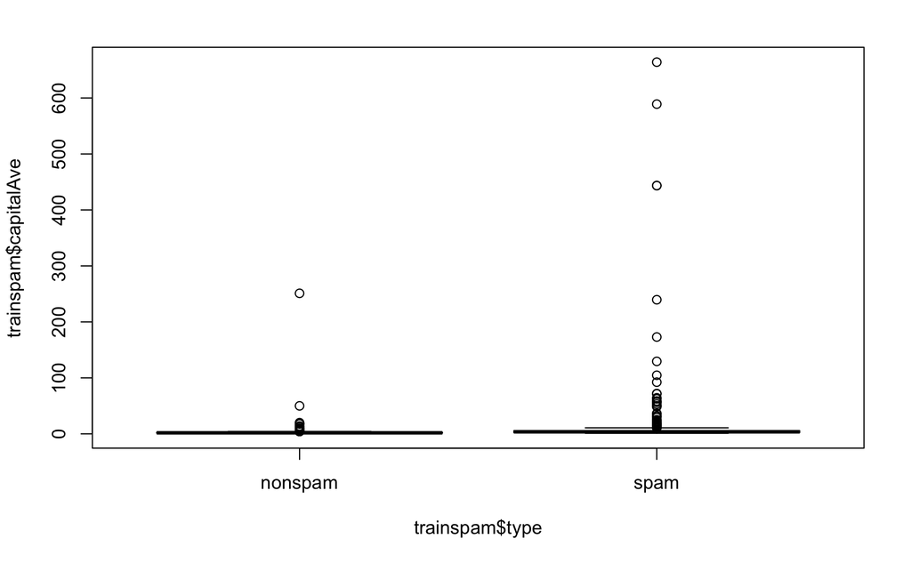

```r
plot(trainspam$capitalAve ~ trainspam$type)
```

Data looks highly skewed, so log transformation is useful. Since there are a lot of 0 in the data, and we are just exploring the data, adding 1 makes sense. Normally we would not do.

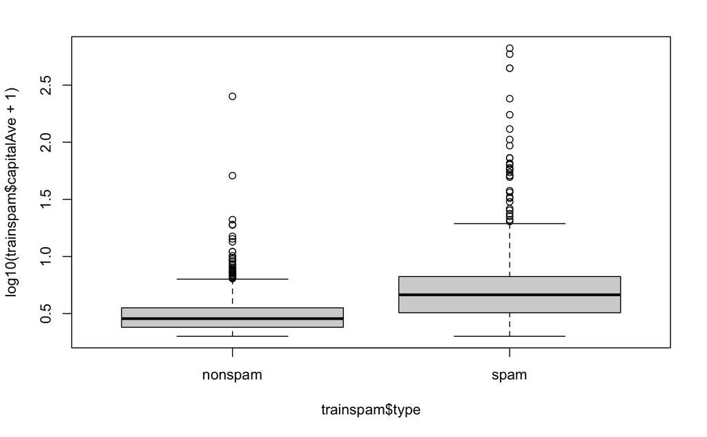

```r
plot(log10(trainspam$capitalAve + 1) ~ trainspam$type)
```

## Pairwise Relationships

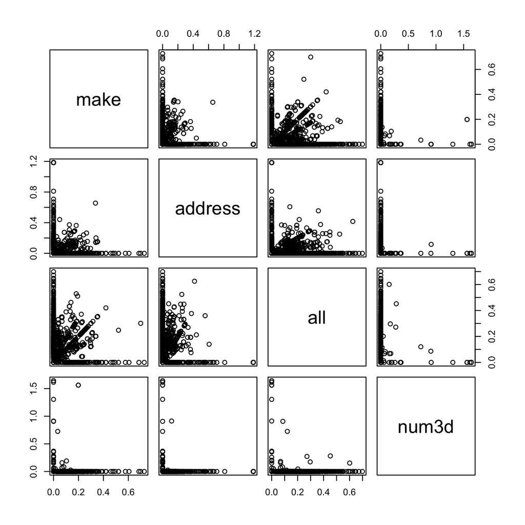

```r
plot((log10(trainspam[, 1:4] + 1)))
```

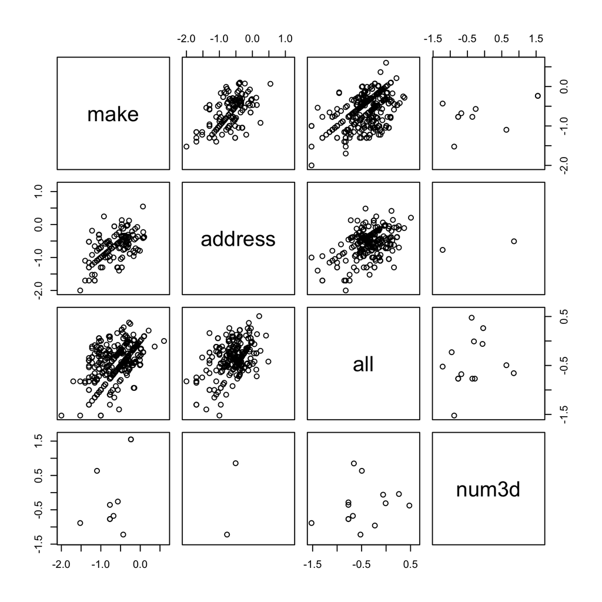

```r
plot(log10(trainspam[, 1:4]))
```

## Clustering

clustering is highly sensitive to skewness of the distribution

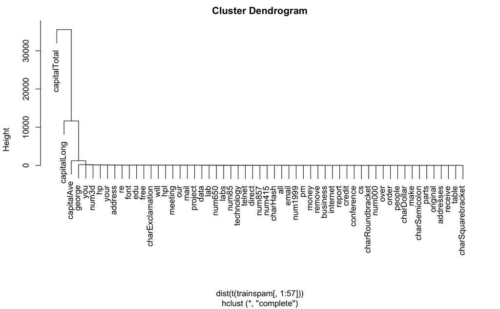

```r
hCluster <- hclust(dist(t(trainspam[, 1:57])))

plot(hCluster)
```

Here we do log transformation

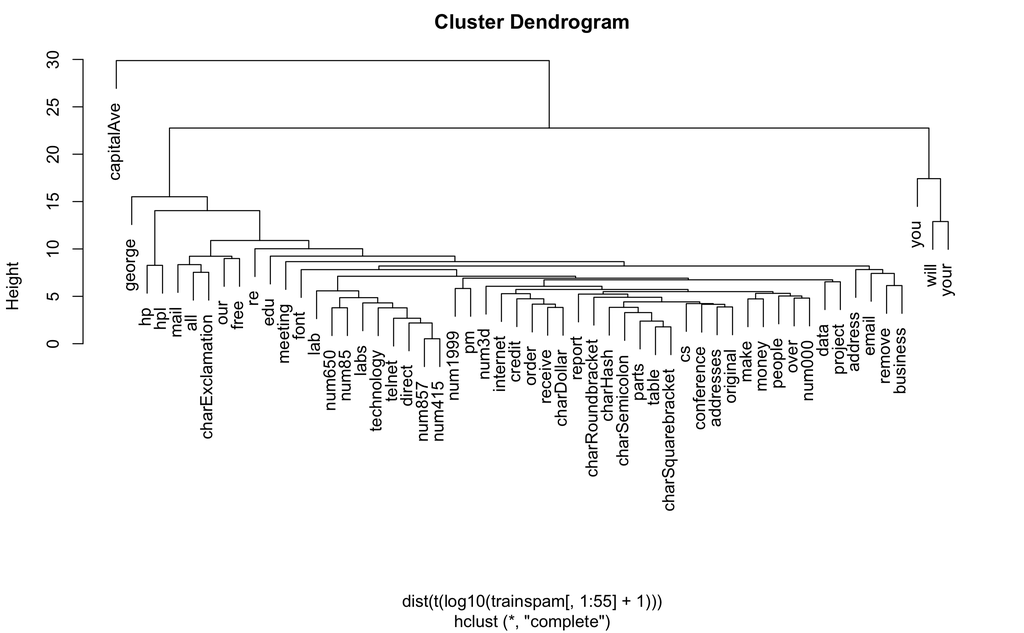

```r
hCluster2 <- hclust(dist(t(log10(trainspam[, 1:55] + 1))))

plot(hCluster2)
```

## Statistical prediction/modeling

```r
trainspam$numtype = as.numeric(trainspam$type) - 1
costfunction <- function(x, y) {sum(x != (y > 0.5))}
cverror <- rep(NA, 55)
```

response: left hand side of the formula

```r
## Which predictor has minimum cross-validated error?
names(trainspam)[which.min(cverror)]
```

[output not shown]

## Get a measure of uncertainty

```r
## use th best model from the group
predictmodel = glm(numtype ~ charDollar, family = "binomial",
                   data = trainspam)
## get predictions on the test set
predictionTest = predict(predictmodel, testspam)
predictedSpam = rep("nonspam", dim(testspam)[1])

## classify as 'spam' for those with prob > 0.5
predictedSpam[predictmodel$fitted > 0.5] = "spam"

predictedSpam2 = rep("nonspam", dim(testspam)[1])
predictedSpam2[predictmodel$fitted > 0.8] = "spam"
```

```r
## classification table
table(predictedSpam, testspam$type)
```

```
predictedSpam nonspam spam
      nonspam    1346  458
      spam         61  449
```

```r
table(predictedSpam2, testspam$type)
```

```
predictedSpam2 nonspam spam
       nonspam    1374  600
       spam         33  307
```

```r
## error rate

(61 + 458)/(1346 + 458 + 61 + 449)
```

```
[1] 0.2242869
```

### this example

- fraction of characters that are dollar signs can be used to predict if an email is a SPAM
- anything with more than 6.6% dollar signs is classified as Spam
- more dollar signs always means more spam under our prediction
- our test set error rate is 22.4%

### challange results

Before anybody does, challenge yourself Challenge all steps: * question * data source * processing * analysis * conclusion

- challenge measures of uncertainty
- challenge choices of terms to include in models
- think of potential alternative analyses

### Synthesize/write-up results

- lead the question (what data, what methodology is appropriate)
- summarize the analysis into the story
- dont include every analysis
- include:
  - if it is needed for the story
  - if it is needed to address a challenge
- order analyses according to the story, rather than chronologically
- include “pretty” figures that contribute to the story

#### In this example

- lead the question:
  - can I use quantitative characteristics of the emails to classify them as SPAM/HAM ?
- Describe the approach
  - collected data from UCI -> created training and test sets
  - explored relationships
  - choose logistic model on training set by cross validation
  - Applied to test data and get 78% accuracy
- interpret results
  - number of dollar signs seems reasonable, e.g. “make money with viagra”$ $ $"
- challenge results
  - 78% is not that great
  - I could use more variables
  - why logistic regression?

## Organizing Analysis

- Data:
  - raw data
  - processed data
- Figures:
  - Exploratory figures
  - final figures
- R code:
  - raw/unused scripts
  - final scripts
  - R markdown
- Text
  - readme files
  - text of analysis/report

**Exploratory Figures - They usually will not be part of the final report - They should be useful but do not have to be polished

** Final Figures - usually small subset of original figures - axes/colors set to make the figure clear - possibly multiple panels

** Raw scripts - less comments - multiple versions - some may be discarded in final

**Final scripts - clearly commented - include processing details - only analyses that appear in the final write-up

** Readme file - if you use Rmarkdown, not necessary - should contain all steps to replicate the analysis

** Text of the document - it should include a title, introduction (motivation), methods, results (includes measures of uncertainty), conclusions (including potential problems) - it should tell a story - it should not include every analysis you performed - references should be included for statistical methods